# Broken Ties: The Impact of Organizational Restructuring on the Stability of Information-Processing N

#### Organizations as the Nexus of IPNs

This study draws on three streams of research that use the network perspective of information processing. The first stream focuses on how the structure of a network influences information and knowledge transfer, while the second places great emphasis on network robustness and channel stability in situations of environmental turmoil. Finally, the third stream pays particular attention to the performance and stability of IT-enabled virtual communities.

Network Effects on Information/Knowledge Transfer

Networks often serve as backbones that facilitate information and knowledge-based activities within as well as across organizations [43, 57]. Efficient functioning and information processing of a network is essential for survival and competence [40]. For this reason, networks should be established and refined in ways that maintain an optimal information flow. Owen-Smith and Powell [57] posit that organizational forms fundamentally influence the flow of information through a network. A centralized network could be considered efficient when information interactions occur vertically (e.g., information sent from central nodes to peripheral nodes) [1, 69]. Depending on various contexts of informational requirements, however, less centralized network formation (e.g., smaller hubs) is preferred [73], especially when task-related environments are highly uncertain and tight clustering and autonomy of work groups are necessary. This structural design enhances information exchange at the work group level, and can effectively facilitate mutual adjustments among peripheral local nodes [69]. Furthermore, such local cluster arrangements reduce the processing load assigned to the central node, as peripheral nodes do not need to communicate directly with the central authority whenever a decision-making situation arises [73].

Recently, several network forms that vary from the two extremes (e.g., highly centralized or decentralized) have been applied extensively to the analysis of the patterns of organizational information processing. For example, the “small-world” network, in which a high degree of local clustering and only a small number of links between any two nodes exist, was found to enhance mutual dependence among cluster nodes and facilitate routine communications among actors, especially when tight collaboration is necessary for connecting value chains within the organization [51, 59]. The availability of such short paths for “bridging” nodes enhances coordination and adaptation of the network, particularly when transferring information across heterogeneous or between distant groups [5]. Moreover, such network properties are effective when diffusing new ideas and innovation in complex organizations [8].

Network Robustness and Channel Stability in Environmental Turmoil

The second stream of research focuses on how organizations reconfigure their information-processing protocols in the event of environmental destruction [24, 51, 62]. Environmental changes influence the patterns through which organizations process information and thus often result in undesirable consequences, such as concentration

of information traffic, excessive overload, bottlenecks, slowdown of flow, and even failure. For example, when one of its essential suppliers, Aisin, was faced with a destructive crisis [51],<sup>2</sup> Toyota and its partners formed an emergent interorganizational information network that enabled them to dampen unexpected “shocks,” supply resources with minimal delays, and recover systems in short periods of time [17]. The informational infrastructures across firm boundaries helped mitigate potential information overload, delays, and congestion-related failure, while protecting the network from complete disintegration [24].

Although this case is an illustration of an interorganizational network, such disruptions or impediments in information flow could also occur within an organization, especially when certain members do not perform their information-processing responsibilities, or voluntarily or involuntarily leave the organization. Similarly, when certain nodes in the network experience information overload, the flow of the rest of the network can be affected and often severely damaged.

Stability and Performance of Online Communities

Based on a case study, Ahuja and Carley [1] found that the fit between network structure and task routines influences member perceptions of performance. More specifically, this study showed that the degree to which network-based coordination is centralized or decentralized in relation to task characteristics is associated with several perceived performance dimensions. Butler [12] investigated the stability of online communities in terms of membership loss and membership gain, both of which affect the form of network-based coordination. Our study extends this line of research by exploring the ways in which such coordination structures are reconfigured following membership loss. Based on over 2.6 million postings extracted from 600 Usenet groups, Jones et al. [39] found that members of online communities tend to stop their active participation as the overloading of mass interaction increases. This finding suggests that as the number of participants increases, the level of activity of existing online members decreases. Finally, Oh and Jeon [55] demonstrated that the stability and integrity of online open source communities are influenced by the herding propensity of their members. They argued that the herding behavior of online community participants in terms of their membership decisions could significantly alter the structure of the community network through which they communicate and exchange knowledge. Building on these studies, we propose a research framework by which one can identify various ontological structures of IPNs and explore their inherent strengths under conditions of organizational restructuring.

#### Organizational Downsizing

Because of the industrial and economic importance of downsizing and structural redesign, as well as their obvious impact on the fabric of society, a significant body of literature has tapped into a variety of issues related to these phenomena. Typical topics include antecedents [11, 30] and consequences of corporate downsizing [14],

the process of an effective job layoff plan [22, 30], the psychological effects of layoffs on remaining employees [10], and the impact of staff reduction on the structure of social networks [62].

When organizational restructuring takes place in the form of downsizing, workload transfers from laid-off employees to surviving employees are almost inevitable. Although IT and other communication mechanisms may replace laid-off employees to a certain extent by facilitating coordination and control among the various organizational components [58], a large portion of tasks will likely be redistributed to the “survivors” who remain in the company [48]. Consequently, the change in workforce composition may require a fine-tuning of work processes and repartitioning of workloads, and as a result, the volume and nature of survivors’ job responsibilities will change [10, 30]. Although much has been written about the consequences of downsizing, its impact on information processing among organizational members has been relatively ignored, especially in regard to those who are linked and highly dependent on IT for communication and information processing. To address this gap, this study approaches the issue from the perspective of IPN-based coordination.

#### Ontological Structures of IPNs

IN THE LITERATURE, NETWORK STRUCTURE has been generally defined as “the arrangement of the differentiated elements that can be recognized as the patterned flows of information in a communication network” [61, p. 82]. Network structures are physically manifest conduits of coordination that illustrate specific patterns of communication and information processing [53]. Several studies (e.g., [1, 55]) suggest that the structure of coordination can vary in response to different internal and external uncertainties. Similar to the characteristics observed in traditional organizational designs, the structures of IPNs manifest either centralized or decentralized formations [1]. Variations in degree of centralization suggest different levels of efficiency and efficacy embedded in the management of information-processing requirements. Based on the literature on network theory (e.g., [2]), we further decompose each structure into two categories (see Figure 1). For example, random and small-world network structures are classified as decentralized IPN designs, whereas MSF and HSF or Barabasi structures represent centralized forms of IPN. We offer detailed descriptions of these classifications and delineate the unique characteristics of each IPN based on the discussion of Dorogovtsev and Mendes [25].

Two important characteristics of network-based information processing are described in order to distinguish one type of structure from another. One of the most obvious and widely discussed characteristics of networks is the probability that a node (i.e., employee) will have *k* connections. This is usually denoted as *P*(*k*), which can also depend on the total number of nodes, *N*, and the total number of edges (connections), *M*. If *P*(*k*) is highly peaked at a single finite value,<sup>3</sup> almost all the nodes will have approximately the same number of “neighbors.” Hence, in this case the network is homogeneous and decentralized. In contrast, if *P*(*k*) has no obvious peak, then the number of connections will vary widely from node to node, leading to a heterogeneous

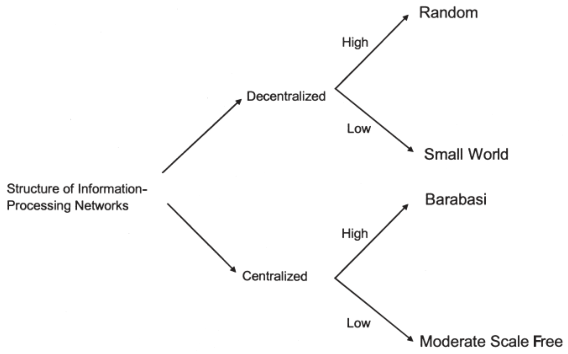

and centralized structure. In addition, if there exists a relatively small number of nodes that hog large chunks of connections, then the information-processing structure is considered centralized. Therefore, the heterogeneity or homogeneity of network structures depends on the distribution of connections, which has significant implications for effective information processing.

#### Decentralized Networks

Random Structure

In the early 1960s, Erdos and Renyi [27] introduced, based on graph theory, random network models in which node connections are evenly distributed and no single node dominates all the connections (see Figure 2a). In their theoretical derivation, regardless of the complexity of the network, all nodes are roughly equal in terms of their *importance* in a given network. In this network structure, nodes are distributed according to a Poisson distribution, which results in small path lengths and sparse concentrations.

Theoretically, there are two types of random coordination structures—equilibrium and nonequilibrium. The nonequilibrium random network refers to a *growing* network in which nodes and edges are simultaneously added. Consider the growth process in which nodes are added to an existing network at regular time intervals. Each new node is then randomly connected to several existing nodes. On the surface, this process should result in a random network in the sense that the connections are distributed according to a Poisson distribution. However, this may not be the case when older nodes accumulate more nodes than the newer ones, because they have had more opportunity

*Figure 1.* A Topology of Information-Processing Networks

(a) Random Coordination (b) Small-World Coordination

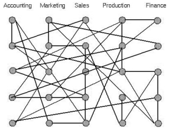

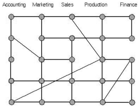

(c) Moderate Scale-Free Coordination (d) Barabasi Coordination

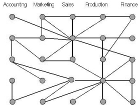

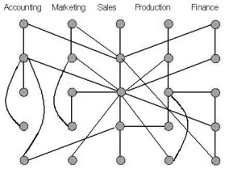

*Figure 2.* Four Types of Information-Processing Networks

to “get connected.” Ultimately, this pattern of growth results in an exponential type of edge distribution *P*(*k*) ~ exp(–*ak*), in which the coefficient *a* depends on the average number of connections per node. An equilibrium (static) situation can be reached when growth stops (i.e., the number of nodes and edges are fixed) and random “rewiring” takes over. When sufficient random rewiring has taken place, then the distinction between newer and older nodes disappears and the distribution of edges becomes Poissonian. As will be explained below, in our simulation, either of these situations can occur in both the formation of an initial IPN structure and in the reconnection of nodes following a downsizing episode. In the equilibrium random network, it is well known that edge distribution follows the Poissonian form:

*P*(*k*) = *e*<sup>–<</sup>*<sup>k</sup>*<sup>></sup><*k*>*<sup>k</sup>*/*k*! (1)

where <*k*> is the average number of connections per node [27]. For this informationprocessing design, the clustering coefficient is also easy to determine. Because, by definition, there is no correlation in the connection of any two given nodes in this type of network, the clustering coefficient, or the probability that A and B are connected to

each other when they are both connected to C, is simply given by the ratio of the total number of edges *M* and all possible connections between *N* nodes:

*c* = *M*/[*N*(*N* – 1)/2]. (2)

Although this information-processing structure may not be as common as other forms, it can be seen in a purely decentralized structure in which all employees within the organization communicate laterally, process a fairly similar amount of information, and have an equal share of responsibility (Table 1). Hinds and Kiesler [37] argue that technical workers (e.g., software engineers) rely extensively on lateral communication because of the nature of the work they perform and the way they are organized. Similarly, Ahuja and Carley [1] posit that nonroutine tasks can be better performed through lateral communication and under the nonhierarchical coordination form. These random network designs may therefore be more suitable for knowledge-intensive industries, such as biotechnology, software engineering, R&D, and consulting [46], in which people rely heavily on lateral communication and information processing for collaborative tasks.

Small-World Structure

During the late 1960s, Stanley Milgram (e.g., [68]) conducted an interesting experiment that uncovered some intriguing results concerning the characteristics of “human networks.” The results showed that it may only take six intercessors to link all the people on earth. Terms such as *small-world networks* or *six degrees of separation* are used metaphorically to refer to the close proximity of all the human nodes on the planet. More recently, Watts and Strogatz [74] made a crucial discovery regarding the theoretical characteristics of small-world networks. They demonstrated that smallworld networks fall into a category between a regular network and a random network with respect to their degree of randomness. On one hand, each node in a small-world structure is embedded in a local cluster, and thus the small-world network possesses a higher clustering coefficient than does the random network (see Figure 2b). On the other hand, short paths that directly connect two nodes located spatially distant from each other, a characteristic typically seen in random networks, are also present in small-world networks. For example, an employee in the sales department can easily coordinate with someone in the production department (Figure 2). These shortcuts provide easy access to most of the nodes in the network, while local clustering tends to foster reliable accessibility [75]. In terms of degree of centralization, small-world networks are more centralized than random networks due to the high number of local clusters, but not at the level inherent to centralized networks.

This type of network structure can represent an efficient form of IPN, especially in situations in which employees use IT to work closely together as team members. Characteristically, these information-processing archetypes are similar in spirit to “organic” or “matrix” type structures [19] in that they allow both autonomy and redundancy in task design. However, small-world networks as information-processing structures are not as constraining as traditional mechanical designs due to their decentralized,

Table 1. The Network Structures and Organizational Contexts

[output not shown]

lateral, and flat design (see Figure 2b). Moreover, this information-processing pattern allows liaison devices to connect across different groups, similar to the traditional “adhocracy” structure [47] that aims to encourage mutual adjustment and collaboration among members. Typically, a small-world network can be formed either by randomly rewiring a portion of an existing regular network [74] or attaching each new node to a “neighborhood” that already exists. A network formed in the first manner would resemble an adhocracy, whereas a network formed in the second manner would consist of concentrated neighborhoods with only a few bridges between the neighborhoods.

#### Centralized Networks

Scale-Free Structure

This study considers two types of scale-free structures—moderate and high. These two structures differ in terms of their degree of centrality—MSF and HSF or Barabasi. Barabasi structures exhibit a much higher level of centrality than do MSF structures (see Figures 2c and 2d). Unlike decentralized networks, these centralized networks form a stratified structure in which the node connections are inhomogeneously distributed and concentrated on certain key nodes. In contrast to random or small-world networks, in which each node has a similar degree of importance, these hub nodes serve as primary information conduits that carry much higher importance in the network than do regular nodes. Interestingly, the scale-free network promotes a *cumulative advantage,* through which key nodes attract new nodes in large numbers [16]. The idea underlying this preferential attachment phenomenon stems from the “Matthew effect,” in which success breeds success [44]. Barabasi [3] also observes a similar trend, in which 80 percent of all World Wide Web connections are “occupied” by only 20 percent of “hub” Web sites. Mathematically, a scale-free network is defined by its power law connection probability

*P*(*k*) = *Ck*<sup>–</sup><sup>γ</sup>, (3)

where C is the normalization constant that depends on the minimum and the maximum number of nodes allowed. The name *scale free* derives from the fact that in such a power law function, any portion of the function looks exactly the same as the whole function, except for the overall normalization constant. This is particularly apparent in a log-log plot, where the plot of *P*(*k*) is a straight line with a slope of –γ.

In general, the majority of nodes in such network structures have a small number of connections, similar to exponential distribution. What is different in the case of scale-free networks, however, is the nonnegligible probability that a node will possess a large number of connections. Therefore, in a large scale-free network, the central nodes are directly connected to a large portion of the whole population. The exponent γ is a parameter that controls what portion of the nodes in the network can be regarded as central nodes. For a small γ whose value is much lower than 1, *P*(*k*) does not change noticeably as *k* changes. The existence of central nodes for a small γ is therefore not important. In nature and human society alike, the typical range for γ is between about 1.5 and 4.

As illustrated earlier, we constructed and analyzed two scale-free structures—MSF (γ = 2) and Barabasi (γ = 2.7). The degrees of γ are determined by the number of nodes and connections employed in the simulation. Because the MSF network design integrates local centralized hubs, organizations with specialty-based expert groups, such as universities, hospitals, and law firms, may use this type of IPN (Table 1). These organizations represent local cliques centering on elite professionals, and are usually less standardized and less centralized than administrative bureaucracies. The Barabasi network represents a form of highly centralized scale-free network, showing a power law distribution much higher than that seen in a typical scale-free network. This type of IPN is subject to the *preferential attachment* effect, in which the idea that “the rich get richer” applies to the connection of new nodes to existing ones. In practice, this type of structure is likely to be found in companies in which a few key individuals dominate most communication and information-processing activities. These key nodes can be considered the leaders of each unit, whose responsibilities include overseeing all work processes, and exchanging and distributing all the information required by their functional areas. Similar design structures can be observed in organizations that are managed via strong commands from key people, such as entrepreneurs. Important decisions will be highly dependent upon communication with these key people. This type of coordination is therefore characterized by a centralized authority who oversees and manages the entire operation by means of direct supervision and control. Many small-sized, less-established companies with a low level of formalization (i.e., entrepreneurial firms) may use this type of information processing until they grow and mature to a point at which differentiation and integration processes become necessary.

Figure 2 is a schematic representation of the four types of IPN structures that exist in contemporary organizations. In random and small-world networks, the network connections are generally sparse and relatively evenly distributed, whereas in centralized networks (particularly in Barabasi networks), only a few nodes dominate a significant portion of all the information connections. It should be noted that the goal of this study is not to empirically validate in which organizations or contexts each IPN structure tends to be observed but rather to conceptually articulate various ontological forms of network structures and the stability of each structure in the event of downsizing.

#### Organizational Restructuring and IPNs

THERE HAS BEEN MUCH ANECDOTAL EVIDENCE demonstrating the perils of organizational shrinkage [66]. However, most scholarly literature thus far has focused mainly on the consequences of downsizing at the individual level (e.g., psychological effects [such as anxiety, depression, or cynicism] of downsizing on survivors who remain at the firm). Through the network framework, we provide a different perspective on the effects of downsizing by investigating, at the network level, the changes occurring in IPNs as a result of workforce reduction. If the main objective of downsizing is not to reduce output but rather to contain costs and improve organizational efficiencies through enhancement of employees’ work productivity, then surviving employees can be significantly affected by such organizational interventions. Because fewer employees remain to do the same amount of work, management must reallocate resources

and work processes, forcing the surviving employees to process or transfer higher amounts of information [13]. Kozlowski et al. [41] noted that when workforce reduction occurs, those who have survived tend to experience “burnout” as their workload typically doubles or triples. This burnout through increased workload is the particular situation on which we focus in this paper.

For any given coordination structure, there is a corresponding information network similar to the one shown in Figure 3. Each person in this coordination design is an information conduit. The *importance* of a person’s position in the IPN can be quantified by various measures, such as the number of connections and the degree of “betweenness.” In any well-functioning IPN, the importance of a person should be well within his or her capacity to deal with the demands of the position (Figure 3a). When the coordination network is downsized, the information paths connecting the downsized nodes must be rerouted to the surviving members of the coordination design. For example, when *N*1 is laid off and *N*2 takes over the tasks previously performed by *N*1, the communication and information-processing structure will be shifted, resulting in a network similar to Figure 3b. This reorganization is likely to change the structure of the coordination network, as well as the importance of various nodes. If the newly acquired importance is within a person’s abilities, then he or she will still function adequately and the connections will be kept “alive.”

In contrast, if the newly acquired importance in terms of information processing exceeds a person’s capacity, then “burnout” may result, and the person will do the minimum required as an information conduit. This, in turn, can lead to a cascading failure, much like the failure of an overloaded electric power grid. The connections that pass through a burned-out node will have difficulty properly carrying or processing information. This will then provoke another round of rerouting and another shift in the relative importance of various nodes. In turn, this can lead to another bout of burnouts, which causes another rerouting cycle. This iteration scenario may not be seen or detected within a company over a short period of time, but it is more likely to occur over a long period. In cases in which downsizing is a recurring phenomenon within the company, the probability that this vicious cycle will occur is not negligible. When this process of rerouting and burnout eventually terminates, the IPN will still be functioning, but on a much smaller scale. If this process does not terminate, then eventually the outcome will be a totally fractured IPN in which no passing of information between nodes is possible. Assuming that the vicious cycle of downsizing does occur, we examine whether IPN structures (centralized or decentralized) matter in terms of reducing the damage created by the vicious cycle.

We also considered two alternative mechanisms by which the nodes (i.e., surviving employees) may be reconnected in the occurrence of workforce shrinkage. The two reconnection modes can be construed implicitly as either “planned” (preferential) or “unplanned” (random) tactics [1]. Some downsizing projects may be well thought out, fully planned, and smoothly executed over a long-term time horizon, whereas others may take place abruptly and in an unplanned manner, primarily in the form of a “discontinuous change” [30] as a response to rapid market shifts. Through the use of the preferential attachment mechanism—as observed in centralized coordi-

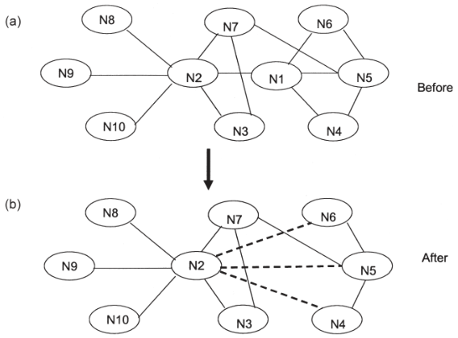

nation structures—the tasks performed by those dismissed prior to downsizing are likely to be reassigned to the nodes with maximum information-processing capacity. Conversely, when firms are not well prepared for downsizing, they may not know the most productive way of reconnecting the “detached wires,” and hence they may arbitrarily reassign them to existing nodes. Below are propositions that are empirically tested through carefully designed computer simulations, which will be described in the next section.

*Proposition 1: Downsizing influences employee efficiency and integrity of the IPN.*

*Proposition 2: The structure of the IPN mediates the impact of downsizing on employees’ efficiency and network integrity.*

*Proposition 3: The reconnection strategy following downsizing (i.e., random versus preferential) and the magnitude of downsizing matter with respect to employee efficiency and the integrity of coordination.*

#### Research Methods

A COMPUTER SIMULATION METHOD WAS CHOSEN as a primary research tool to answer the underlying questions at hand for several reasons. First, computer simulation is a robust method that provides a holistic approach to the analysis of a real-world situation

*Figure 3.* Reallocation of Workload After Downsizing

[65]. Such controlled experimental designs enable us to assess the patterns through which IPNs evolve and how the overall performance of each structure changes in the event of downsizing. Second, simulation modeling offers flexibility and robustness in terms of validating various aspects of theoretical propositions. In particular, computer simulations have been considered suitable tools for understanding the details of complex network properties [15].

To carry out the simulation, it is crucial that we accurately quantify the importance of a position as well as the skills of the individual holding the position within the structure of the IPN. Many traditional measures are used to assess the importance of a node in a given network, including number of connections and various betweenness measures such as geodesics and flow betweenness [71]. Each of these measures has its own strengths and weaknesses in cases in which the information passed between two nodes does not necessarily follow a set pattern. In this study, we use a recently proposed measure called “random walk betweenness,” which remedies some of the shortcomings of previous betweenness measures [51]. Until recently, the most popular betweenness measure was geodesic betweenness, which is defined as the ratio of the number of geodesics (i.e., the shortest path between two nodes in a given network) that pass through a given node to the number of all possible pairs. This measure is generally a legitimate indicator of the importance of a node, except when there are nearly geodesic paths that could also be potentially important. Random walk betweenness, in contrast, is illustrated as follows: suppose that every node in the IPN sends a message to everyone else. Further, suppose that each message knows only its destination and does not have any information on how to get there. Then each message has to perform random walks through the coordination network until it finds the destination. In this respect, “random walk betweenness” can be defined as the number of times that the message passes through *i* on its journey, averaged over a large number of trials of the random walk [50, 51]. It can be shown that this result is equivalent to the sum of currents that pass through each node in an equal-strength resistor network. Hence, the tools of *circuit analysis* (e.g., [7]) can be directly used to calculate random walk betweenness once the adjacency matrix is given.

Geodesic betweenness and random walk betweenness are well correlated as shown by Newman [51]; however, random walk betweenness is more robust in the sense that the nearly geodesic paths that should be important in any real-world situation are also correctly accounted for. For this reason, therefore, we use random walk betweenness to assess the importance of a given node (person) in IPN, as well as to quantify the skills of the person.

#### Network Simulation Procedures

As noted earlier, this study considers four ontological IPN structures that exist in various organizations—random, small world, MSF, and Barabasi. To construct a random IPN structure, we first determined the number of nodes and the total number of connections. In our case, we chose 100 nodes and 200 connections (an average of four neighbors per node). This size is considered “sufficiently” large to reflect real-world

situations. We then randomly chose a “not-yet-connected” pair 200 times and connected them with a link. The resulting distribution of the number of neighbors is known to be a Poisson distribution, as illustrated earlier. It peaked at four by construction, and most nodes fell within the range of two to six. It is worth noting that a node with a large number of neighbors is exponentially rare in this type of IPN structure. The small-world network was constructed as follows: similar to the procedures specified in designing random networks, we first constructed a regular network of 100 nodes arranging it in a 10 × 10 square form. To make all the nodes retain the same number of connections, the square’s opposing edges are connected to each other. In this way, all nodes have four connections. We then randomly removed 20 percent of the connections and randomly rewired the same number of connections. Compared to the regular network, these random connections (“shortcuts”) reduce the average distance between pairs of nodes, for example, from 5.05 (regular network) to 3.71 (small-world network) in our simulation.

To construct an MSF network with γ = 2, we first assigned the number of connections to each node according to the γ = 2 distribution and connected the nodes so that no loose ends remained. More specifically, similar to the procedures described earlier, we started with 100 nodes. To each node, we first assigned the number of neighbors according to *P*(*k*) so that the total number of connections was approximately 200. Then, starting from the most connected node, random connections between the nodes were made until each node was connected to the assigned number of neighbors. Finally, the Barabasi network was constructed through the use of a simple set of “the rich get richer” rules. The preferential attachment principle (an instance of the Matthew effect) was used to construct the Barabasi network. Specifically, we adhered to the following rules [2] at each time step: (1) with the probability *p*, we randomly picked an existing node and linked it to another existing node with the probability that it is proportional to the number of neighbors (preferential attachment); (2) with the probability *q*, we randomly relinked an existing connection; and (3) with the probability of 1 – *p* – *q*, we added a node with *m* connections to the existing nodes, again attaching preferentially. The result, with *p* = 0.1 and *q* = 0.3, was a Barabasi network with γ = 2.7.

The simulation started at *t* = 0 by constructing one of the four networks described above. The random walk betweenness for the initial network configuration was then calculated using the tools of circuit analysis as described by Newman [51]. Assuming that such a network is well functioning, we set the ability (capacity) of each node to be 1.5 times its initial betweenness value. At *t* = 1, we then downsized the coordination network by removing nodes from the bottom of the betweenness ranking (i.e., employees who do not add much value to the company). The links that the removed nodes had occupied were then reconnected to the existing nodes either preferentially (i.e., “the rich get richer”) or randomly (this reconnection strategy is discussed below). The betweenness values were then recalculated. At *t* = 2, the first stage of burnout sweeps through the existing clusters. Any node whose betweenness exceeded its capacity to handle it would burn out and thus be unable to efficiently coordinate work processes. In contrast to downsizing, the links of a burned-out node were not reattached to the existing nodes, because a burned-out node is still technically a part of an existing

network. After the first stage of burnout, we again calculated betweenness, and then repeated the burnout procedure until either no more burnout occurred or every node was burned out (see the Appendix for detailed simulation procedures).

#### Performance Measures

Two performance measures (i.e., employee efficiency and network integrity) were employed to analyze the simulation-generated data. Employee efficiency, measured by workload performed divided by his or her capacity, indicates the extent to which an employee handles information-processing workload vis-à-vis his or her capacity. In general, a low number (say, below 0.5) indicates that a worker is not performing at his or her best, while a high number (say, over 1) suggests that a person is exceeding his or her workload capacity. In other words, low numbers indicate slack resources, while high numbers indicate resource shortages and potential employee burnouts. The other measure adopted—network integrity—shows the level of integrity of the IPN. A high ratio suggests that nodes within the IPN are well connected to each other, while a low ratio suggests fragmentation. Therefore, the higher the ratio of this measure, the greater the level of integrity of the IPN. It should be noted that while employee efficiency measures the effect of downsizing from an individual perspective, the integrity variable identifies its impact on the network as a whole. Therefore, the two results should be interpreted as complementary rather than competing.

#### Moderating Variables

To reflect real-world situations more precisely, we added two moderating variables that might influence the results. The first represents the scale of downsizing, which was divided into two categories—“light” (10 percent) and “heavy” (40 percent) downsizing. It is reasonable to assume that the magnitude of downsizing significantly influences the restructuring outcome. Typically, a light downsizing strategy is driven by a desire to achieve “incremental benefits,” such as operational efficiencies without high risk; a heavy downsizing strategy, in contrast, is intended to refine entire key organizational components such as strategy, mission, and structure [30]. It is important to note that because downsizing is likely to be a recurring phenomenon [64], it is necessary to understand its magnitude over a longer time horizon.

Finally, as discussed earlier, we considered two options a company might have in terms of reconnecting the “broken” nodes that resulted from downsizing (e.g., planned and unplanned reconnection strategies). With regard to specific downsizing decision rules, we assumed that companies lay off “rummies” who are the least efficient and underperform in their assigned tasks (i.e., those who have low value based on random walk betweenness) [66].

#### Results and Discussion

AS EXPLAINED ABOVE, THE SIMULATION MODEL consists of several variables: (1) four network designs (i.e., random, small world, MSF, and Barabasi), (2) two moderating

variables (i.e., the downsizing magnitude and reconnection tactics), and (3) two performance measures (i.e., employee efficiency and network integrity). We first show the results as they pertain to employee efficiency and then explain how network structure affects the stability of an IPN in the event of downsizing.